[output not shown]

keywords : “Graphic Communication, Pragmatics, Symbol-Referent-Relationships, Iconicity, Representation, Analogical Reasoning”

```r
# aggregate proportion of correct choices and number of trials for each individual
rep_difficultyplot.data  <- rep.data %>%
  filter(valid != "drop" & trial != "NA") %>%
  group_by(study, title, condition, subid, agey, aged) %>%
  arrange(condition, subid, agey, aged) %>%
  summarise("correct" = round(mean(correct)*100, 2),
            "trials" = length(valid))

difficulty.plot <- ggplot(rep_difficultyplot.data,
                    aes(x=reorder(condition, -correct), y=correct, colour = condition)) +
  geom_hline(yintercept=50, linetype="dashed", color = "black") +
  geom_boxplot() +
  geom_jitter() +
  theme_minimal() +
  theme(legend.position = "none")

difficulty.plot
```

[output not shown]

```r
# Developmental Plots for each study without facetting by condition

# plot 1 #####################
plot_all_S1 <- ggplot() +
  geom_hline(yintercept = 0.5, linetype = "dashed", color = "grey70", alpha = 0.75) +

  geom_point(
    data = d1,
    aes(x = ageinyears, y = mean, colour = colour),
    alpha = 0.5, shape = 1, size = 2
  ) +

  geom_smooth(
    data = f1,
    aes(x = age, y = Estimate, ymin = Q2.5, ymax = Q97.5, fill = colour, colour = colour),
    stat = "identity", alpha = 0.2, linewidth = 0.8
  ) +

  # shape 21 uses both fill (inside) and colour (stroke)
  geom_point(
    data = p1,
    aes(x = days/365.25, y = 0.5, fill = colour, colour = colour),
    size = 4, shape = 21, stroke = 1
  ) +

  # constant black overlay: set outside aes()
  geom_point(
    data = p1,
    aes(x = days/365.25, y = 0.5),
    fill = "black", colour = "black", size = 0.5, shape = 21, stroke = 1
  ) +

  # text: move color/fontface outside aes()
  geom_text(
    data = p1,
    aes(label = months, x = days/365.25, y = 0.13),
    color = "black", fontface = "bold",
    angle = 90, size = 3, vjust = 0.5
  ) +

  geom_text(
    data = p1,
    aes(label = "months", x = days/365.25, y = .31),
    color = "black", fontface = "bold",
    angle = 90, size = 3, vjust = 0.5
  ) +

  scale_colour_identity() +
  scale_fill_identity() +
  scale_y_continuous(labels = function(x) paste0(x*100, "%")) +
  labs(x = "Age", y = "Proportion Correct") +
  coord_cartesian(ylim = c(0, 1), xlim = c(2.7, 7.3)) +
  theme_minimal(base_size = 13) +
  theme(
    panel.border = element_rect(colour = "grey30", fill = NA, size = 1),
    strip.text = element_blank(),
    strip.background = element_blank(),
    axis.title = element_text(face = "bold", size = rel(0.8)),
    axis.text = element_text(size = rel(0.8)),
    legend.position = "none",
    panel.grid.minor = element_blank(),
    axis.title.y = element_blank(),
    axis.title.x = element_blank()
  )

# plot 2 #####################
plot_all_S2 <- ggplot() +
  geom_hline(yintercept = 0.5, linetype = "dashed", color = "grey70", alpha = 0.75) +

  geom_point(
    data = d2,
    aes(x = ageinyears, y = mean, colour = colour),
    alpha = 0.5, shape = 1, size = 2
  ) +

  geom_smooth(
    data = f2,
    aes(x = age, y = Estimate, ymin = Q2.5, ymax = Q97.5, fill = colour, colour = colour),
    stat = "identity", alpha = 0.2, linewidth = 0.8
  ) +

  # shape 21 uses both fill (inside) and colour (stroke)
  geom_point(
    data = p2,
    aes(x = days/365.25, y = 0.5, fill = colour, colour = colour),
    size = 4, shape = 21, stroke = 1
  ) +

  # constant black overlay: set outside aes()
  geom_point(
    data = p2,
    aes(x = days/365.25, y = 0.5),
    fill = "black", colour = "black", size = 0.5, shape = 21, stroke = 1
  ) +

  # text: move color/fontface outside aes()
  geom_text(
    data = p2,
    aes(label = months, x = days/365.25, y = 0.13),
    color = "black", fontface = "bold",
    angle = 90, size = 3, vjust = 0.5
  ) +

  geom_text(
    data = p2,
    aes(label = "months", x = days/365.25, y = .31),
    color = "black", fontface = "bold",
    angle = 90, size = 3, vjust = 0.5
  ) +

  scale_colour_identity() +
  scale_fill_identity() +
  scale_y_continuous(labels = function(x) paste0(x*100, "%")) +
  labs(x = "Age", y = "Proportion Correct") +
  coord_cartesian(ylim = c(0, 1), xlim = c(2.7, 7.3)) +
  theme_minimal(base_size = 13) +
  theme(
    panel.border = element_rect(colour = "grey30", fill = NA, size = 1),
    strip.text = element_blank(),
    strip.background = element_blank(),
    axis.title = element_text(face = "bold", size = rel(0.8)),
    axis.text = element_text(size = rel(0.8)),
    legend.position = "none",
    panel.grid.minor = element_blank(),
    axis.title.y = element_blank(),
    axis.title.x = element_blank()
  )

# plot 3 #####################
plot_all_S3 <- ggplot() +
  geom_hline(yintercept = 0.5, linetype = "dashed", color = "grey70", alpha = 0.75) +

  geom_point(
    data = d3,
    aes(x = ageinyears, y = mean, colour = colour),
    alpha = 0.5, shape = 1, size = 2
  ) +

  geom_smooth(
    data = f3,
    aes(x = age, y = Estimate, ymin = Q2.5, ymax = Q97.5, fill = colour, colour = colour),
    stat = "identity", alpha = 0.2, linewidth = 0.8
  ) +

  # shape 21 uses both fill (inside) and colour (stroke)
  geom_point(
    data = p3,
    aes(x = days/365.25, y = 0.5, fill = colour, colour = colour),
    size = 4, shape = 21, stroke = 1
  ) +

  # constant black overlay: set outside aes()
  geom_point(
    data = p3,
    aes(x = days/365.25, y = 0.5),
    fill = "black", colour = "black", size = 0.5, shape = 21, stroke = 1
  ) +

  # text: move color/fontface outside aes()
  geom_text(
    data = p3,
    aes(label = months, x = days/365.25, y = 0.13),
    color = "black", fontface = "bold",
    angle = 90, size = 3, vjust = 0.5
  ) +

  geom_text(
    data = p3,
    aes(label = "months", x = days/365.25, y = .31),
    color = "black", fontface = "bold",
    angle = 90, size = 3, vjust = 0.5
  ) +

  scale_colour_identity() +
  scale_fill_identity() +
  scale_y_continuous(labels = function(x) paste0(x*100, "%")) +
  labs(x = "Age", y = "Proportion Correct") +
  coord_cartesian(ylim = c(0, 1), xlim = c(2.7, 7.3)) +
  theme_minimal(base_size = 13) +
  theme(
    panel.border = element_rect(colour = "grey30", fill = NA, size = 1),
    strip.text = element_blank(),
    strip.background = element_blank(),
    axis.title = element_text(face = "bold", size = rel(0.8)),
    axis.text = element_text(size = rel(0.8)),
    legend.position = "none",
    panel.grid.minor = element_blank(),
    axis.title.y = element_blank(),
    axis.title.x = element_blank()
  )

# combining plots ----------------------------------------------

S1_complete <- ggdraw() +
  draw_plot(plot1, y = 0, x =  0.01, width = .25, height = .44) +
  draw_plot(plot2, y = 0, x =  0.25, width = .25, height = .44) +
  draw_plot(plot3, y = 0, x =  0.5, width = .25, height = .44) +
  draw_plot(plot4, y = 0, x =  0.75, width = .25, height = .44) +
  draw_plot_label(label = "A", size = 14, x = 0, y = 0.89) +
  draw_plot_label(label = "B", size = 14, x = 0, y = 0.65) +
  draw_plot_label(label = "C", size = 14, x = 0, y = 0.26)

library(gridExtra)
grid.arrange(plot_all_S1, plot_all_S2, plot_all_S3, ncol = 1)
```

[output not shown]

```r
# create plot 1 -----------------

current_data <- d1 %>%
  mutate(yearofage = floor(ageinyears)) %>%
  mutate(yearofage = paste0(yearofage, "-year-olds")) %>%
  mutate(yearofage = as.factor(yearofage)) %>%
  mutate(yearofage = fct_rev(yearofage))

# set spread
pd <- position_dodge(width = 0.4)

boxplot_S1 <- ggplot(current_data, aes(x = condition, y = mean, group = subid)) +
  geom_violin(
    aes(group = condition, fill = colour),
    alpha = 0.15,      # Very faint
    color = NA,        # No outline
    trim = TRUE
  ) +

  geom_line(
    position = pd,
    color = "grey80",
    alpha = 0.3
  ) +

  geom_point(
    aes(color = colour),
    position = pd,
    alpha = 0.4,
    size = 1.2
  ) +

  # geom_boxplot(
  #   aes(group = condition, fill = colour),
  #   width = 0.1,       # Makes it skinny
  #   outlier.shape = NA, # Dots are already plotted
  #   alpha = 0.5,
  #   color = "grey30"    # Darker border for contrast
  # ) +

  # 5. Layout and Faceting
  facet_wrap(~yearofage, ncol = 1) +
  theme_minimal() +
  labs(
    title = "Study 1 - Representation and Form Analogy",
    x = "Condition",
    y = "Percentage of Correct Choices"
  ) +
  scale_y_continuous(labels = function(x) paste0(x*100, "%")) +
  theme(legend.position = "none")


# create plot 2 -----------------

current_data <- d2 %>%
  mutate(yearofage = floor(ageinyears)) %>%
  mutate(yearofage = paste0(yearofage, "-year-olds")) %>%
  mutate(yearofage = as.factor(yearofage)) %>%
  mutate(yearofage = fct_rev(yearofage))

# set spread
pd <- position_dodge(width = 0.4)

boxplot_S2 <- ggplot(current_data, aes(x = condition, y = mean, group = subid)) +
  geom_violin(
    aes(group = condition, fill = colour),
    alpha = 0.15,      # Very faint
    color = NA,        # No outline
    trim = TRUE
  ) +

  geom_line(
    position = pd,
    color = "grey80",
    alpha = 0.3
  ) +

  geom_point(
    aes(color = colour),
    position = pd,
    alpha = 0.4,
    size = 1.2
  ) +

  # geom_boxplot(
  #   aes(group = condition, fill = colour),
  #   width = 0.1,       # Makes it skinny
  #   outlier.shape = NA, # Dots are already plotted
  #   alpha = 0.5,
  #   color = "grey30"    # Darker border for contrast
  # ) +

  # 5. Layout and Faceting
  facet_wrap(~yearofage, ncol = 1) +
  theme_minimal() +
  labs(
    title = "Study 2 - Orientation and Position",
    x = "Condition",
    y = "Percentage of Correct Choices"
  ) +
  scale_y_continuous(labels = function(x) paste0(x*100, "%")) +
  theme(legend.position = "none")


# create plot 3 -------

current_data <- d3 %>%
  mutate(yearofage = floor(ageinyears)) %>%
  mutate(yearofage = paste0(yearofage, "-year-olds")) %>%
  mutate(yearofage = as.factor(yearofage)) %>%
  mutate(yearofage = fct_rev(yearofage))

# set spread
pd <- position_dodge(width = 0.4)

boxplot_S3 <- ggplot(current_data, aes(x = condition, y = mean, group = subid)) +
  geom_violin(
    aes(group = condition, fill = colour),
    alpha = 0.15,      # Very faint
    color = NA,        # No outline
    trim = TRUE
  ) +

  geom_line(
    position = pd,
    color = "grey80",
    alpha = 0.3
  ) +

  geom_point(
    aes(color = colour),
    position = pd,
    alpha = 0.4,
    size = 1.2
  ) +

  # geom_boxplot(
  #   aes(group = condition, fill = colour),
  #   width = 0.1,       # Makes it skinny
  #   outlier.shape = NA, # Dots are already plotted
  #   alpha = 0.5,
  #   color = "grey30"    # Darker border for contrast
  # ) +

  # 5. Layout and Faceting
  facet_wrap(~yearofage, ncol = 1) +
  theme_minimal() +
  labs(
    title = "Study 3 - Size and Number",
    x = "Condition",
    y = "Percentage of Correct Choices"
  ) +
  scale_y_continuous(labels = function(x) paste0(x*100, "%")) +
  theme(legend.position = "none")

# check plots ------

boxplot_S1

boxplot_S2

boxplot_S3
```

[output not shown]

## Lay Summary (max. 120 words)

Young children are skilled at understanding spoken language and gestures, but much less is known about how they make sense of graphic communication. We explored how children aged 3 to 7 interpret unfamiliar graphic displays in a picture-book-style game of hide and seek where they had to choose the correct hiding place based on a drawn cue. Across three studies, we tested many kinds of symbol–object relationships, ranging from clear pictures to abstract cues based on shape, size, number, orientation or spatial arrangement. Children followed representational drawings at three, but the understanding of more abstract symbols emerged around the fourth birthday. These findings show how children gradually learn to find meaning in increasingly complex visual symbols even prior to literacy.

# Introduction

Children’s developing understanding of symbols in language, gesture or symbolic artefacts is central to their enculturation and demonstrates cognitive capacities that define the human mind [@Tomasello2014natural; @Vygotsky1980mind]. The acquisition of language and – much later – literacy [@Dehaene2009reading; @Bruner1996culture; @olson1994world] are arguably two of the most significant achievements in cultural learning that individuals undergo with dramatic consequences for their cognitive abilities [@karmiloff1994beyond]. In order to better understand the underlying processes, researchers have worked on gesture, words, photographs, representative drawings, maps, models, simulacra, figurines and sound symbolism [@callaghan2015development].

The work of Judy DeLoache and colleagues has been of seminal importance in sketching children’s ability to exploit the informative value of symbolic artefacts. In various studies, they have prompted children to find the location of a hidden toy by providing them with cues in the form of scale models, pictures, videos and maps representing a search space [@deloache2004becoming]. Whereas even 30-month-old children fail to retrieve hidden items by using instructions based on replicas like a model-room, 36-month-olds excel. This pattern of results in symbolic object-choice-tasks has been replicated many times by her group and other labs [@deloache2011early] and demonstrates that children’s symbolic understanding undergoes a rapid development in the third year of life [@deloache2004becoming; @callaghan2015development].

A similar developmental trajectory has been observed in the understanding of graphic representations. Iconicity provides an entry point in this domain and even in the first year, infants are sensitive to the similarity between a picture and its 3D referent [@deloache1998grasping]. While pictures can incite manual exploration before the first birthday [@pierroutsakos2003infants] this is replaced with pointing to the depiction in the second year [@deloache1998grasping]. Around the same age, toddlers understand that pictures refer to concepts [@allen2004both] in learning words: 15- and 18-month-olds can extend newly learned labels both from pictures to objects and from objects to pictures [@ganea2008transfer]. From 2,5 to 4, children use the shape of drawings to interpret them as long as the drawings are presented to them as having been produced intentionally [@gelman1998shape]. Yet, Callaghan [-@callaghan1999early] found that two-year-olds were still at chance selecting an item depicted in representative drawings whereas three- and four-year-olds succeeded. Children’s comprehension of graphic depictions remains fragile until the end of the third year. Callaghan [-@callaghan2000factors] presented children either with a realistic pencil drawing, a stylized drawing or a replica model and then prompted children to choose what was depicted from a set of two referents. 30-months-olds did not benefit from iconicity and failed to use pictures and replicas as symbols. 36-month-olds succeeded in all conditions and benefitted from iconicity and the availability of verbal labels during the task [@callaghan2000factors; @DeLoache1995early].

Matching graphic representations with each other is much less demanding or even so trivial that it is rarely employed in experimental contexts. Finding a graphical item in a drawn scene as is often done in picture-book reading routines or visual search paradigms and is generally accessible for children at the end of the third year [@gerhardstein2002development]. Matching identical items in match-to-sample tasks is occasionally used as a training in research on analogical reasoning and generally provides no challenge for children older than three [@kroupin2022you].

On the other hand, it may be possible to establish reference drawing on more abstract or conceptual symbol-referent relationships such as size, number, orientation, position or gestalt principles.

Direct investigations into children’s ability to use symbol-referent relationships other than similarity or iconicity in the graphic domain are rare. Given that graphical representations are static in time and limited to 2D-space, the conceptual dimensions along which information can be encoded is finite. Apart from representations capturing the actual shape of what they are depicting, discussions of graphic communication generally identify primitives or “visual variables” as fundamental elements for encoding information. These variables are position, size, number, orientation, relational and gestalt-principles, as well as continuous visual properties such as brightness, color (hue) or texture [@cleveland1984graphical; @stevenson2014visual]. The former group takes precedence in conceptual implementation due to their discreteness. After all, a conventional sign or representative drawing can evoke the same concept regardless of the color or brightness it is implemented with. On the perceptual level, object, color, quantity, size are easier to process than relational properties or figural analogies such as orientation and position [@stevenson2014visual; @donnelly2007visual]. Similar successions have been documented throughout the preschool years. Children are first able to understand iconic signs or depictions around the third birthday, whereas more conceptual or analogical dimensions are appreciated only at four to five years of age [@callaghan2000factors]. Defining the precise ages and relative developmental trajectories for children’s sensitivity to using these graphic primitives as conveying meaning and disambiguating reference provides crucial insights into children’s developing symbolic competence.

PARS PRO TOTO

Omissions in depiction are an important aspect of developing conventions and streamlining communication [@goldin1977development] as well as they are an interesting minimal step towards abstraction as they are still basically iconic, yet only showing a part or aspect of the target. At least for basic geometrical shapes, we know that while the production and completion of shapes in drawing [@cox2005pictorial; @daugli2016young] develops throughout the preschool years, shape recognition and naming are robust in the third and fourth year [@ZAMBRZYCKA2017144; @verdine2017shape; @verdine2016shape] and the ability to mentally complete canonical geometric shapes is already nascent in early infancy [@kellman1983perception; @valenza2006perceptual], making part-whole relationships on the level of geometric figures an ideal target for an investigation into slightly abstract symbol-reference relationships that young children may be able to read at the beginning of the preschool years.

FORM ANALOGY

A highly abstract means of reference that is still rooted in iconicity may be the metaphorical use of form or shape, for example, by referring to something pointy, sharp or spiky with an edgy or more clear cut rectangular drawing [@knoeferle2017drives]. Again, this is common in language and became a focus of research studying sound symbolism in the lexicon [@bermudez2020sound; @sidhu2025sound], as well as actions and gesture [@margiotoudi2020action; @bohn2019natural]. The phenomenon is robust across cultures [@cwiek2022bouba] and children appear sensitive to sound symbolism matching words and shapes by about 30 months of age [@maurer2006shape; @imai2008sound; @fort2018symbouki] and for matching actions with gestures or vocalizations at 36 months [@bohn2019natural]. **There is currently no data on whether children are sensitive to an agreement in the overall properties of a shape or the impression that its form conveys for grounding reference.**

GESTALT

As with the other dimensions reported above, there is evidence that children are sensitive to Gestalt principles like closure and spatial dimensions of composition position, orientation and alignment in graphic displays but there is virtually no data on how likely children are to perceive such aspects of graphical stimuli to convey meaning. Closure appears to be a basic principle for graphic production, as children rarely draw overlapping figures [@cox2005pictorial; @piaget1997mental]. Relative position is intuitively used by children even in their earliest figural drawings when arranging items in scenes, such as children next to an ice-cream van, but also when achieving “intellectual realism” in depicting complex objects [@luquet2001children]. That is, while children’s drawings may not look realistic per se, they are true to the invariant organisation of a depicted item via the relative position of the defining elements: when drawing a car, the wheels will be added at the bottom rather than on top [@cox2005pictorial]. In both cases, relative position and orientation on the level of the individual object or scene may be discussed as iconic. A more abstract or conceptual use of relative position for conveying information is present in children’s developing ability to read maps. An intuitive understanding of basic maps allowing children to extract relational directions such as “behind me” or “in front of me” is accessible by four years of age and even so in the absence of training [@landau1986early] but iconicity is again very important for grasping the conceptual space depicted in maps [@liben2013role]. Likewise, 4-year-olds can use geometric information from maps to navigate real space [@shusterman2008young], but the more demanding transfer from maps to real-world settings with larger spatial arrays is unstable prior to six to seven years of age [@uttal1989young; @blades1994development].

SIZE

Size is a relative property of graphical content and requires a comparison between items, for example when drawing a big and small dog, or an appreciation of an item’s relation to the frame of reference it occurs in, as when a child may try to convey the concept of a big dog by making it occupy the entire piece of paper it is drawing on [@cox2005pictorial]. Children are able to make spontaneous or productive size comparisons at three years of age and begin to use size words (*big*), size superlatives (*biggest*), or quantifiers (more, most) [@ferry2025bigger], yet young children are most accurate with *bigger* and only gradually gain competence with words like smaller, shorter or longer [@frausel2020origins]. When presented with an array of graphic stimuli, preschoolers can reliably point at, for example, the smallest or largest item in a set [@haun2011conformity]. While three- and four-year-olds can identify larger or smaller graphic items, the canonical size of the depicted objects can interfere leading to stroop-like errors [@long2019real]. When presented with three different geometric shapes in matching or non-matching dimensions (e.g. large, large, small) in match-to-sample tasks, children are quite unlikely to spontaneously infer size as the basis for matching even around the fourth birthday [@kroupin2022you]. One of the few studies using size as a way for grounding reference, investigated the role of the producers intentions in identifying concepts in ambiguous scribble drawings that were presented to participants as aiming to depict, for example, a small spider next to a big house. Children here made use of spatial analogies beginning at three years of age but appeared to benefit more as they turned four [@bloom1998intention].

NUMBER

Number, is another relational concept, and an absolute primitive in graphic communication [@ifrah2000universal; @cooperrider2019career] likely to be the conceptual space that the very first historic systems of writing were trying to capture. Judgments of quantity have been studied extensively in developmental psychology and identified both implicit and explicit number systems [@carey2019ontogenetic]. Infants already have an implicit proximate grasp of differences in number [@starr2013number] with one versus three being one of the most early comparisons possible, which is also frequently used as the most simple tasks in comparative work [@eckert2022does; @xu2007number; @carey2000origin]. Preschoolers growing up in industrialized environments are constantly surrounded by math tasks in the form of various games [@daucourt2021home] as well as preschool curricula incentivizing a playful engagement with quantities, number symbols and shapes [@kucharz2012elementarbildung; @schmidt2021fruhpadagogische]. By four years of age, children have a basic grasp of the cardinal principle, that is basic understanding of the relation of number words and fixed quantities [@silver2022environmental; @carey2019ontogenetic] and they are able to use that knowledge in practical everyday contexts, for example when comparing comparing numbers with magnitudes smaller than five [@wynn1990children]. In match-to-sample tasks, children spontaneously infer number as a basis of comparison between four and five years of age [@kroupin2022you].

From this review of children’s ability to appreciate various basic dimensions of graphic depictions and their sensitivity to these as means for conveying information, we can identify a couple of research desiderata. Most striking is the literature’s focus on similarity and iconicity [@callaghan2015development]. Mappings between symbol and referent can take place along a number of conceptual dimensions and few studies explicitly address these. Against this background, a systematic and comprehensive investigation of the conceptual dimensions along which graphic symbols can be imbued with meaning, will help to evaluate the extent to which children’s competence is specific to certain types of symbol-referent-relationships or generalizes across mappings based on analogy in form, size, number, or Gestalt principles.

By contrast, the studies below investigate young children’s spontaneous comprehension of unfamiliar graphic symbols that gain meaning from being produced in a specific and highly restricted context where symbol and referent align in certain conceptual dimensions with decreasing iconicity. Therefore, they focus on children’s pragmatic competencies and their ability to identify shared features across graphic displays used as cue and target. To the extent that children are highly unlikely to have encountered the specific graphic cues used here, our findings showcase their ability to grasp and acquire novel symbol-referent pairings. This may limit the influence of children’s knowledge of conventional symbols on performance and make results more robust and informative for research about the acquisition or emergence of communicative systems despite spanning an age-range where children become competent users of script, numerals or drawings.

# General Methods

All studies presented below share methodological and analytic approaches. For the convenience of the reader, common features of the procedure, participant recruiting and stimulus design are reported first before discussing the three studies respectively. All studies were preregistered online prior to data collection (cf. [Study 1](https://aspredicted.org/SJT_H7F): https://aspredicted.org/SJT_H7F, [Study 2](https://aspredicted.org/L2H_XC7): https://aspredicted.org/L2H_XC7, and [Study 3](https://aspredicted.org/DR4_B4B): https://aspredicted.org/DR4_B4B). All stimuli, experiments, data and analyses are available at: https://github.com/GregorKachel/symlit_rep_manuscript.

## Data Collection and Setup

In order to continuously trace the development of symbolic competences across the preschool years, for each study we aimed to test a minimum of two children per month of age between the third and the seventh birthday for a total of 96 participants balancing male and female participants. As children participated on the basis of availability and data were collected by several experimenter teams in parallel, the final samples slightly exceed this preregistered minimum sample size. The final sample approximates an equal distribution of male and female participants and aligns with conventions in the field in providing a minimum of 24 participants per study and year of age. For an overview of the distribution of all children included in the analyses across the age-range see supplement figure 1. Figure 2 from the supplements shows the age-distribution of all children that participated but were not submitted to analyses due to the exclusion criteria outlined below. All participants were recruited in Leipzig, a medium-sized European city, and came from a predominantly white population of middle to high income families. Children were largely tested in day- and after school-care, and occasionally in the lab or at home. Data collection took place from June 2022 to February 2023.

## Setup and Procedure

During test sessions, a child and an experimenter sat down together to play a picture-book-style hiding game presented on a touch-screen laptop. Verbal instructions were played back by the experimental script. Experimenters supervised children and occasionally reacted with a fixed set of verbal prompts when children were not following the presentation (“Oh look, the game continues!”). See figure @ref(fig:plot-figure-setup) A for an illustration of the setup.

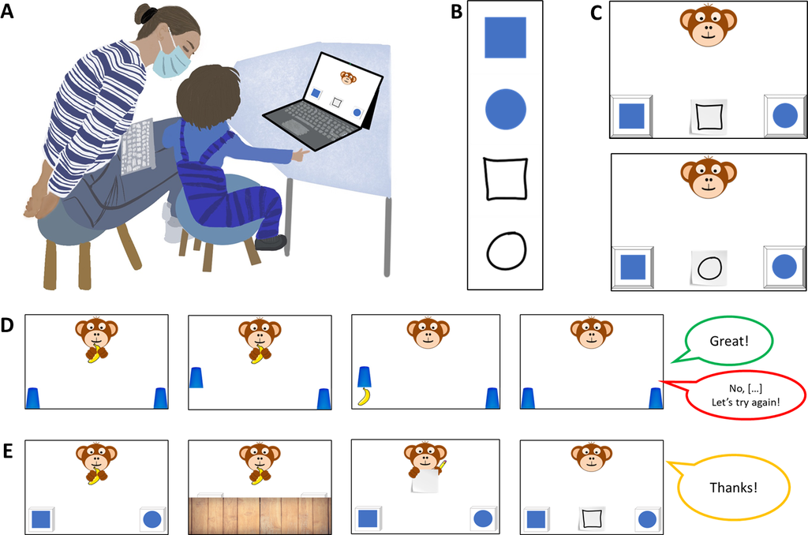

*Setup, Stimuli and Trial Structure.* Panel A shows the setup during testing. Experimenters were sitting behind the children in order to not distract them while supervising data collection. Panel B shows all elements contributing to an item of a possible test trial consisting of two choice options and one of two possible cues. Panel C exemplifies how two choice options and one of the cues were arranged for a specific test trial. Panel D shows a familiarization trial and Panel E shows a test trial.

*Familiarisation.* First, the experimental script introduced a cartoon monkey. This character placed two cups on the bottom left and right side of the screen. After holding up a banana, one of the barriers was lifted, the banana was placed underneath one of the cups and the barrier was lowered. Children were now prompted to touch the hiding place and in doing so the barrier of their choice was lifted to reveal the banana if they chose correctly. The experimental script provided feedback upon children’s choice (“yes, great job!”; “No, that’s not it. Let’s try again!”) during the familiarization (cf. figure @ref(fig:plot-figure-setup) D). To ensure that children were familiar with the goal of the game and the touch interface, they first had to complete a set of four to eight familiarization trials with a success rate of 75%. In case a child did not reply correctly in three out of four trials, another four familiarization trials were provided. If the child was correct in six out of eight trials, she was included in the main sample. Children that did not succeed were allowed to participate but their data was not submitted to analysis.

*Test.* The main phase of the study commenced with announcing that the cartoon character had an idea for a new game. Now, children were not allowed to see where the banana would be hidden, but that the monkey would help them find it. The cartoon character was established as a knowledgeable and benevolent partner in a cooperative coordination game. After the hiding phase, the monkey held up a piece of paper and a pencil. Pencil movement and a short scribble sound indicated that the monkey was drawing. Finally, participants were prompted with the phrase “Where is the banana?” and the monkey’s drawing was placed in the center between the two hiding places. The drawing served as a cue to guide children’s choice. Children’s choice was acknowledged with neutral feedback (“Ah, thank you”) leading to the next trial (cf. figure @ref(fig:plot-figure-setup) E).

A single trial lasted roughly 20 to 60 seconds, depending on how swiftly children chose. Each study presented four different experimental conditions with four trials each in a blocked order for a maximum of 16 test trials. Unique combinations of graphic displays were used on every trial. Test sessions lasted about 12 minutes in total. The order of conditions was counterbalanced across participants. Children occasionally wished to stop before completing all trials, resulting in minor deviations of the total number of trials per condition that were submitted to analysis. For an overview of the average number of trials participants received in each condition, see supplementary materials. In line with the preregistration, children had to complete a minimum of eight test trials to be included in analysis.

## Stimuli and Counterbalancing

The context in the studies presented below is provided by a game of hide and seek and the options are two hiding places that are distinct by means of the graphic displays they are marked with. The aim was to test at what age children become able to spontaneously match cue and target along various dimensions of symbol-referent relationships. For this, the graphic displays presented as choice options were designed to saliently differ in one relevant dimension and to be as similar as possible with regard to other features. The cue, on the other hand, was a reduced and less straight-lined graphic display akin to a hand drawing that had something in common with one of the choice options and was thereby referring to it. In test trials, one of the choice options serves as a target and the other as a distractor. For counterbalancing, a second cue was designed to refer to the other choice option, such that across participants the same choice options serve equally often as targets and distractors. For an illustration of trial composition, see figure @ref(fig:plot-figure-setup) B and C. For each of the conditions in the three studies below, four sets of stimuli were designed, consisting of two blue shapes serving as target or distractor, and two drawings that could serve as cues. Each condition covers a particular type of symbol-referent relationship via four stimulus versions with two variations each. For an example, consider figure @ref(fig:plot-study1). The first box in Panel B shows all stimuli for the *Representation* condition. The first column exemplifies a set of targets (a blue square and circle) and cues (outline drawings of a square and circle). During test, participants are presented with four test trials per condition, each composed of the shapes of a single column. During testing, a child sees each trial combination only once and with only one of the two possible cues. Across children, the position (left/right) of the target, and the identity of the cue are counterbalanced. For the convenience of the reader, all stimuli employed across studies are presented with the results for each condition in figures @ref(fig:plot-study1), @ref(fig:plot-study2), and @ref(fig:plot-study3) respectively.

## Data Handling and Analyses

Upon touching the screen, children’s choices were logged and immediately coded as correct or incorrect by the code running the stimulus presentation. To evaluate how children’s ability to interpret cues varies by age and condition, we employed Bayesian Logistic Generalized Linear Mixed Models (GLMMs). This mode of analysis is appropriate as it allows to estimate the probability of success while accounting for uncertainty and individual differences, and because it allows to map linear predictors to a probability between 0 and 1 via a link function. Our analyses modeled children’s binary choices (correct vs. incorrect) using fixed effects for condition, age as well as their interaction as primary predictors. In addition, we included a fixed effect of trial number, to control for learning or fatigue, and a fixed effect of sex. To account for the possibility that some children may be better at the task than others, we included random intercepts for each participant. We also included random slopes for trial number, allowing potential effects of learning or fatigue to vary from child to child. To facilitate processing and interpretability, age and trial number were standardized to a natural mean of 0 prior to modeling. The full model notation was `correct ~ condition*z.age + z.trial + sex + (z.trial | subid)`. In line with best-practice conventions, we evaluated the relevance of age and condition for children’s performance prior to interpreting coefficients. For this, the full model outlined above was compared with a reduced model lacking the interaction of age and condition. To asses the fit and relative explanatory power of either model, we used Widely Applicable Information Criterion (WAIC) scores and weights [@mcelreath2018statistical] as well as the difference in Expected Log Predictive Density (ELPD) via the function *loo_compare* [@sivula2020uncertainty]. Across all studies, the preregistered full model proved superior or equally predictive. Model estimates were inspected for the different predictors including their 95% Credible Interval (CrI). In each study, the condition hypothesized as the most simple was set as the reference level within conditions. All models were implemented in Stan [@RStan] via the function *brm* of the package *brms* [@burkner2017brms].

In order to answer our main research question of when children systematically perform above chance in each condition, we followed the approach of House and colleagues [@House2013ontogeny] and plotted the model estimates as a smoothed curve surrounded by Credible Intervals (CrI). We generated developmental trajectories with 95% CrIs from the posterior predicted distribution via the function *fitted* and plotted them with children’s age on the horizontal axis and the probability of correct choices on the vertical axis. Chance level was marked via a 50% chance line for orientation. Children as a group were considered to perform above chance only when the lower bound of the 95% CrI no longer overlapped with the 50% chance line (e.g. @ref(fig:plot-study1), @ref(fig:plot-study3), @ref(fig:plot-study3)).

All analyses and our hypotheses about the relative difficulty of conditions were preregistered prior to data collection. However, the specific age-point predictions are exploratory, and our use of ELPD for model comparison [@sivula2020uncertainty] represents a modern refinement over the methods available at the time of preregistration. To additionally evaluate variability at the level of the items tested, additional exploratory analyses included item level random effects (Model notation `correct ~ condition*z.age +z.trial +z.sex +(z.trial|id) +(z.age|item)`). For brevity, tables outlining the coefficients for the final models were moved to the supplementary materials along with the exploratory item-level analyses outlined above. The supplements also provide conventional analyses binning participants according to their age in years for readers that are less familiar with the analyses described above. In the supplements, two-tailed one-sample t-tests with a chance level set to .5 were computed for participants binned according to year of age. Here, Cohen’s *d* is provided as a standardized effect size for significance testing.

# Study 1

Study 1 aimed to establish a baseline for children’s performance and for evaluating task demands by providing the simplest symbol-referent relationship possible, where the cue is a direct representation of the target (*Representation*). From this, three further conditions were derived that were also employing form or shape as a means for establishing reference but that were less iconic by either reducing the amount of information provided (*Pars Pro Toto*), or the amount of similarity between cue and target (*Simple Form Analogy*, *Complex Form Analogy).* Our preregistered hypothesis was that as a group, children will first succeed with *Representation*, then *Pars Pro Toto*, *Simple Form Analogy* and finally *Complex Form Analogy*.

## Stimuli

To make the four conditions in study 1 as comparable as possible, they are all employing the same target stimuli (cf. figure @ref(fig:plot-study1), panels A and B). In addition the two cues within a trial can be seen as the round and square equivalents of each other. For the condition *Representation,* the graphical cue is an outline drawing, of the target. The second condition, *Pars Pro Toto,* refers to the targets by means of a part-whole relationship. This is still in principle representational but provides less information and may require children to complete the shapes according to gestalt principles. While this completion is easiest in the first two items of *Pars pro Toto* due to the canonical shapes (square, circle) it is less obvious with the less canonical shapes albeit they are vertically and horizontally symmetrical on purpose (cf. @ref(fig:plot-study1) B, box 2). For comparability, *Pars Pro Toto* uses the same graphical cues as *Representation* but cut in half at a horizontal mid-line. A Stimulus set of an individual trial either uses the top or bottom half, but both variations are counterbalanced across trials. Two further conditions aimed to abstract from the original representational symbol-referent relationship by providing graphical analogies in form. In both *Simple Form Analogy* and *Complex Form Analogy* the cue was an abstract line drawing being more round or rectangular, thereby referring to either the round or rectangular equivalent of the target shapes. As this has not been done before in developmental research, our aim was to provide two versions of form analogies both supporting children’s comprehension in distinct ways. In *Simple Form Analogy*, the cues are less dense and therefore simpler to grasp, whereas the more complex versions in *Complex Form Analogy* provide more information. For an overview of all stimuli employed in Study 1, see figure @ref(fig:plot-study1) B.

## Participants and Sample

A sample of 106 children (M = 59.1792453 months, SD = 13.58 months, range 36 - 83 months; 51 female) participated in Study 1. In addition, 22 children (11 female) were tested but excluded from analysis for not succeeding during familiarization (N = 13), for not completing at least eight out of 16 test trials (N = 1), or due to being fussy (N = 2). For 4 children, experimenters only learned during testing that they were not fluent enough in German to participate as their families had only recently migrated. Finally, 2 children had to be excluded due to technical issues. A total of 1688 trials (mean per condition = 422, range: 420 - 424) from 106 participants were submitted for analysis.

## Results

Posterior predictive checks (PPC) for both full and null model indicated excellent fit of observed data and model predictions. Rhat values in both models were equal to one, indicating convergence across all chains. Effective sample sizes for all fixed effects in the full model (Bulk ESS, mean = 6222, range 4323 - 1.0098^{4}) and the null model (Bulk ESS, mean = 5777, range 4351 - 8307) were > 1000, indicating reliable posterior estimations.

Comparing the models using weights based on the Widely Applicable Information Criterion (WAIC) yielded 74.52% of the model weight for the full model, and 25.48% for the null model. Hence, the full model generally had a higher probability of making accurate predictions. Directly comparing the models’ WAIC via expected log predictive density (ELPD) corroborates this (ELPD WAIC; full model = -901.11; null model = -903.53). The standard error of the difference in predictive accuracy (SE = 3.14) is not much larger than the difference itself (ELPD diff = -2.42). Hence, evidence in favor of this model is not decisive. A similar comparison via Leave-One-Out Cross-Validation (LOO) provided essentially the same results. In absence of conclusive evidence for either model, we report the results for the full model in line with the preregistration.

Relative to the *Representation* condition, the *Simple Form Analogy* ($\beta$ = -1.3877458, 95% CrI [-1.7499714, -1.0335495]) and *Complex Form Analogy* ($\beta$ = -1.3593425, 95% CrI [-1.7336574, -0.9978891]) have a considerably lower probability of correct responses. The *Pars Pro Toto* condition has no clear difference from the *Representation* condition ($\beta$ = -0.13585, 95% CrI [-0.5446336, 0.275105]). Interaction effects with age were not relevant with the exception of *Pars Pro Toto*. Here, the interaction with age was positive and just above zero ($\beta$ = 0.3028049, 95% CrI [-0.0528531, 0.6690145]), suggesting that performance increased more steeply across the age range than in the *Representation* condition*.* Generally, participants’ performance improved with age in all conditions ($\beta$ = 0.4234195, 95% CrI [0.1335198, 0.7241661]). In contrast, trial number has no clear effect on performance ($\beta$ = -0.0132617, 95% CrI [-0.1469499, 0.1201639]), suggesting no evidence for learning or fatigue throughout the test session. For a side-by-side comparison of the developmental trajectories in the four conditions of study 1 and the respective ages of success, see figure @ref(fig:plot-study1).

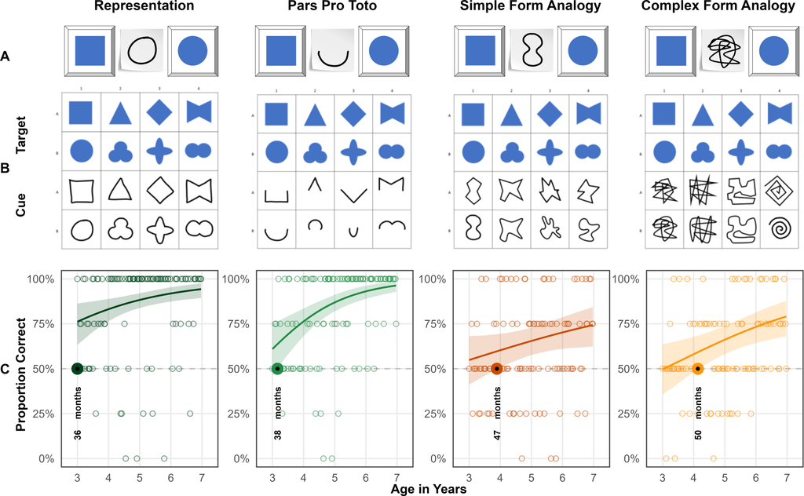

*Stimuli and Developmental Trajectories for Study 1.* Panels illustrate (A) an example stimulus combination (distractor, cue, target), (B) all items of the respective conditions and (C) results. Coloured lines indicate smoothed mean performance by age. Shaded areas represent 95% CIs. The dashed line demarcates chance level and the dots represent individual means. The colored dots and annotation indicate when children’s performance exceeds chance level.

## Discussion

Children perform above chance in the *Representation* condition at least as early as 36 months, which is the lower limit of the age-range. Based on the literature, it is reasonable to assume that also in our setup, children would be able to solve the task at hand between the second and third birthday [@deloache1992picture; @callaghan2000factors; @callaghan1999early]. In the context of all other conditions reported below, this result establishes that the task design and setup are sufficiently clear even for the youngest children in the sample and worked well across the wide age-range of four years from the end of toddlerhood up into school age. *Representation*, thus, provides a robust and clear conceptual canvass against which the developmental patterns of all other symbol-referent relationships can be discussed. Despite using identical targets as in *Representation,* children succeed only at 38 months in *Pars Pro Toto*. The interaction with age shows that performance improves more quickly with age and that the area covered by the upper and lower CrI bounds shrinks considerably across the age range. *Pars Pro Toto*, hence, stands out as a clear example for a task that children come to master early and within the age-range tested here, that generally is not demanding for preschoolers in general. In the more abstract conditions *Simple Form Analogy* and *Complex Form Analogy*, preschoolers meet criterion at 47 and 50 months respectively. Both appear equally difficult for participants and provide examples for symbol-referent relationships that remain demanding for the oldest children in the sample. While they are still based in iconicity, in so far as their interpretation involves a sense of resemblance with regard to their shape [@winter2026defining], they are conceptually demanding at the same time. With regard to the influence of surface features, group level success occurs slightly earlier with the reduced cues employed in *Simple Form Analogy* [@richland2006children]. Finally, the results are perfectly in line with the hypothesized developmental succession of group level success coming to pass first with *Representation*, then *Pars Pro Toto*, *Simple Form Analogy* and *Complex Form Analogy*.

# Study 2

The conditions in study 2 continue to abstract from a representational symbol-referent relationship by using different shapes for both cue and target stimuli. The conditions here, draw on gestalt-principles like figure-ground-relationship, continuity and parallelism. The symbol-referent-relationship in *Absolute Position* is established by the respective cue and target sharing the same position with regard to the reference frame they occur in. In *Relative Position* cue and target are each composed of two shapes. Reference is established by the respective shapes being closer or further apart or sharing a position on a horizontal or vertical axis. For *Orientation of Object*, symbol and cue are aligned along the same axis. The final condition, *Orientation of Feature* employs cue and target shapes with a salient feature that is either oriented up- or downward. The preregistered hypothesis, assumed children to perform above chance first in *Orientation of Object*, then *Orientation of Feature*, *Absolute Position* and finally *Relative Position*.

## Stimuli

For comparability, *Absolute Position* and *Relative Position* employed the same distinct shapes as cue and target respectively (circle vs. square, cross). In *Absolute Position* target positions were placed in top and bottom, or central and peripheral conditions in half of trails. For *Relative Position*, two trials present target stimuli that are closer together or further apart, as well as another two trials with target components being aligned on a horizontal or vertical axis. To ensure that cue and target are maximally distinct in all dimensions, cues and target items do not allign on the same axis. As in study 1, cues and targets are either round and rectangular shapes in these conditions. To convey a sense of direction in *Orientation of Object,* cues and targets feature elongated shapes that are aligned either on a horizontal, vertical, or diagonal axis with rising or falling slope. The shapes are distinct oblong elipses and rectangles or abstract shapes with more or less round or square features. For *Orientation of Feature*, targets and cues are either circles or squares with a salient feature like an opening or a dent. For an overview of all stimuli used in Study 2, see figure @ref(fig:plot-study2).

## Participants and Sample

A total of 99 three- to seven-year-old children (M = 60.040404 months, SD = 13.69 months, range 36 - 83 months; 49 female) participated. None of these children participated in study 1. In addition, a total of 13 children (6 female) were tested but excluded from analysis for failing familiarization (N = 9), being fussy (N = 1), not being fluent enough in German to follow the instructions (N = 1), or due to technical issues (N = 2). A total of 1561 trials (mean per condition = 390.25, range: 388 - 393) from 99 participants were submitted for analysis.

## Results

For both full and null model, PPCs indicate excellent fit of observed data and model predictions. Rhat values in both models were equal to one, indicating convergence across all chains. Effective sample sizes for all fixed effects in the full model (Bulk ESS, mean = 6149, range 3485 - 7545) and the null model (Bulk ESS, mean = 6877, range 3839 - 1.004^{4}) were > 1000, indicating reliable posterior estimations.

To compare model performance, we evaluated the WAIC estimates. The null model showed a slightly better predictive performance (ELPD = -888.15) compared to the full model (ELPD = -889.99). WAIC values also indicate better performance of the null model (WAIC = 1776.3) over the full model (WAIC = 1779.99). However, the difference between models (ELPD Diff = -1.84) falls within the bounds of uncertainty (SE = 1.76), suggesting no advantage in predictive accuracy. Hence, the preregistered analyses using the full model is reported below.

Across all conditions, performance improved with both age ($\beta$ = 0.4029118, 95% CrI [0.1384089, 0.6821517]) and slightly with trial number ($\beta$ = 0.2566753, 95% CrI [0.0988781, 0.4307646]). Relative to *Absolute Position*, children were generally less likely to correctly solve *Relative Position* ($\beta$ = -0.2791929, 95% CrI [-0.6413017, 0.080198]). Performance in *Orientation of Object* ($\beta$ = -0.0974936, 95% CrI [-0.4590597, 0.2686]) and *Orientation of Feature* ($\beta$ = -0.1195334, 95% CrI [-0.4826231, 0.2265286]) was not substantially different from the reference category *Absolute Position* when considering the full age range. Interaction terms between age and condition were not credibly different from zero, suggesting similar developmental patterns for all conditions. For a side-by-side comparison of the developmental trajectories and the respective ages of group-level success, see figure @ref(fig:plot-study2).

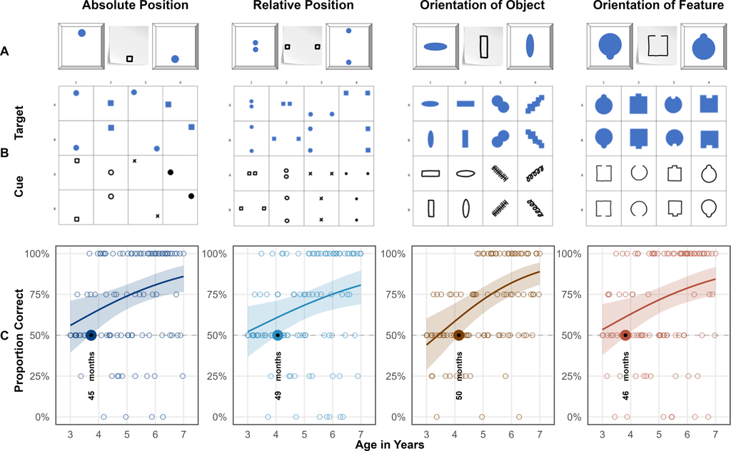

# Study 3

## Stimuli

In *Size of Object* the targets in a each trial are identical shapes that are either small or large with regard to the reference frame they are presented in. To make cue and target shapes as distinct as possible they are again employing either squares or circles respectively or fully abstract shapes such as a random scribble or straight lines (cf. figure @ref(fig:plot-study3) B). For comparability, *Size of Feature* employs the same cues as *Size of Object*, but features target shapes with either a relatively large or small void, opening, or protrusion. In *Number of Object*, cues and targets are composed of different shapes with some being simple line drawings. The displayed quantities were 1 versus 3, and 2 versus 4. Three- and four-year-olds can reliably distinguish these magnitudes explicitly and implicitly without counting [@mix2002quantitative]. Special attention was paid to the arrangement of the objects to ensure that the cue and target objects do not share visually similarity by forming a similar pattern, which is difficult as such small number arrays lend themselves to being grouped into canonical shapes by Gestalt principles such as proximity and closure. This issue was addressed by presenting the targets depicting the magnitudes three and four as if outlining irregular shapes. By contrast, the corresponding cues were aligned along a vertical of horizontal axis. For comparability, *Number of Feature* employs the same cues as *Number of Object*. To evoke a sense of quantity in the closed forms serving as choice options, the target shapes in *Number of Feature* either have salient protrusions, or partial areas resulting from incisions. For an overview of all stimuli presented in Study 3, see figure @ref(fig:plot-study3).

## Participants and Sample

A total of 99 three- to seven-year-old children (M = 59.8787879 months, SD = 13.44 months, range 36 - 83 months; 55 female) participated. None of these had participated in the previous studies. In addition, 23 children (7 female) were tested but excluded for low performance during familiarization (N = 12), for not completing at least eight out of 16 test trials (N = 1), or being fussy (N = 3). Further exclusions were necessary due to language problems (N = 4) and technical issues (N = 3). For study three, 1559 trials (mean per condition = 389.75, range: 388 - 392) from 99 participants were submitted for analysis.

## Results

PPCs indicated excellent fit of observed data and model predictions in both models. Model diagnostics were drawn for the full and null model in study 3. Rhat values in both models were equal to one, indicating convergence across all chains. Effective sample sizes for all fixed effects in the full model (Bulk ESS, mean = 6552, range 4556 - 8586) and the null model (Bulk ESS, mean = 7253, range 5531 - 8885) were > 1000, indicating reliable posterior estimations.

When comparing performance, the full model showed a better fit (ELPD = -941.75) relative to the null model (ELPD = -945.94). The WAIC values also favored the full model (WAIC = 1883.49) over the null model (WAIC = 1891.88). Despite the slightly lower WAIC and higher ELPD of the full model, the difference in predictive accuracy (ELPD Diff = -4.19) remains almost within the range of sampling uncertainty (SE = 3.97). In the absence of substantial differences, the full model is reported below in line with the preregistration.

Overall, children’s performance increased with age ($\beta$ = 0.7007479, 95% CrI [0.4376467, 0.9691644]) and with trial number ($\beta$ = 0.2087633, 95% CrI [0.0575986, 0.3581511]), indicating general improvement across development and time-on-task. Relative to *Size of Object*, participants were substantially less accurate in *Size of Feature* (beta = -0.709714, 95% CrI [-1.0648271, -0.3627148]). A smaller, marginal effect was observed in *Number of Feature* ($\beta$ = -0.3116933, 95% CrI [-0.6704726,0.0499463]). *Number of Object* ($\beta$ = -0.0818486, 95% CrI [-0.4303847, 0.2769006]) did not differ reliably from *Size of Object*. Age moderated performance less strongly in *Size of Feature* ($\beta$ = -0.504693, 95% CrI [-0.8194342, -0.1960757]) and *Number of Feature* ($\beta$ = -0.2853723, 95% CrI [-0.6011151, 0.0322548]), suggesting lower developmental gains compared to *Size of Object*. Generally, the conditions relying on feature-based reference are associated with lower overall performance and weaker developmental gains. The best overview of the relative performance across conditions and the corresponding age of success is provided by plotting the model estimates (cf. figure @ref(fig:plot-study3)).

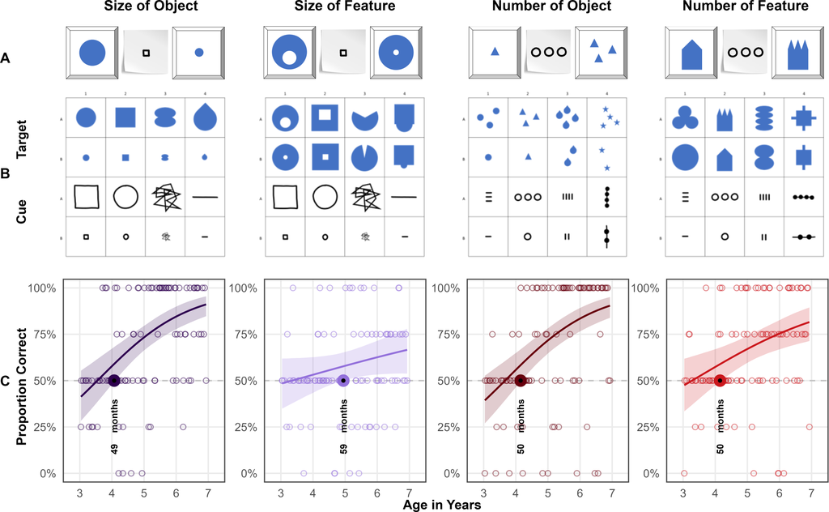

*Developmental Trajectories for all Conditions in Study 3.* Panels illustrate example stimulus combinations (distractor, cue, target) and results. Coloured lines indicate smoothed mean performance by age. Shaded areas represent 95% CrIs. The dashed line demarcates chance level and the dots represent individual means. The coloured dots and annotation indicate when performance exceeds chance level.

# Discussion

We presented a concerted three-part research project tracing young children’s ability to spontaneously use unfamiliar graphic displays as communicative cues in an object-choice task across a wide variety of symbol-referent relationships. In three studies with four conditions each, we collected data of two children per month of age continuously from the third to the seventh birthday for a final sample of 304 children (Study 1, N = 106; Study 2, N = 99; Study 3, N = 99). We determined the month of age at which children as a group perform above chance with each symbol-referent relationship using Bayesian GLMMs. Across the various conditions, symbolic reference between cue and target was established via direct representation, a part-whole relationship, analogies in size, number and shape, as well as gestalt-like principles like figure-ground relationships, orientation and alignment. While previous work on graphic communication has focused almost exclusively on iconicity as a way of creating meaning and compared performance across binned age-groups, the three studies presented here map development continuously using a highly simple and streamlined procedure across various conceptual dimensions.

By design, the three studies provide a conservative test case of children’s ability to find meaning in the symbol-referent relationships presented. Participants are never directly instructed to search specific similarities across cue and target nor prompted to find matches per se as is commonly done in match-to-sample designs (e.g. “Which ones go together?”). Rather children were told that their interlocutor would like to help them find an item in a game of hide and seek and would create a drawing for them. Children then had to infer that the interlocutors drawings my be read as novel symbolic cues referring to either choice option. To prevent learning or demand effects across trials, children did not receive feedback for their responses and were presented with a novel stimulus pairing in each trial.

Study 3 set out to further reduce iconicity by drawing abstract analogies in size and number. *Number of Object* featured graphic displays with one or three items for target and distractor. *Number of Feature* reuses the same cues but employs targets varying in number with regard to salient features (e.g., spikes or dents). Children succeed in both conditions at 50 months. A different pattern emerges for the two conditions featuring size relationships. Children succeed at 49 months of age in *Size of Object*, but ten months later in *Size of Feature* in which target and distractor figures have a small or large opening, bump or hole. This aligns with research showing that while preschoolers are generally sensitive to the canonical size of objects depicted in graphical displays [@long2019real; @cox2005pictorial; @bloom1998intention] they are much less likely to spontaneously extract size relations among abstract shapes [@kroupin2022you].

To the extent that the studies presented above highlight the fourth birthday as a milestone in symbolic development, this connects to a rich literature on major developmental shifts in this period of middle-childhood. As change at this age is again rapid and foundational across a variety of cognitive processes [@karmiloff1994beyond; @rakoczy2022foundations], several factors are likely to contribute to the convergence of above-chance performance across the experimental conditions used here. What has been described as the four-year-revolution in social cognition endows children with a full-fledged metarepresentational theory of mind and firmly developed belief-desire psychology [@rakoczy2022foundations; @wellman2001meta; @gopnik1988children]. Theory of mind performance, in turn, was shown to be correlated with representational insight into the standing-for-relationship of pictorial representations [@callaghan2012young], as well as insight into communicative intent [@callaghan2008children], and major shifts in perspective-taking abilities [@flavell1981young]. All of which are necessary or conducive for the flexible and spontaneous interpretation of graphic displays as well as inference-based or pragmatically challenging communicative behavior broadly construed. Specifically helpful for the tasks employed here may be developmental gains typically occurring around the fourth birthday in the domain of analogical reasoning [@shivaram2023children; @christie2014language; @gentner1977children], which are again fostered by growth in working memory [@simms2018working; @richland2006children], executive functions [@thibaut2010development; @bohn2023individual] and inhibitory control [@carlson2007inhibitory; @jablonski2014inhibitory].

While work on analogical reasoning abilities has highlighted that preschoolers are generally able to identify agreement in graphic displays and specifically involving size, number, and shape also at the age of four [@kroupin2022you; @kroupin2022importance], this has mostly been established in match-to-sample paradigms where children are conventionally presented with three items and prompted with a phrase such as “which ones go together” directly inducing the cognitive operation tested. In our task, children make matches and comparisons across various dimensions without any verbal scaffolding addressing the match-making process or the dimension of comparison and, hence, showcases abilities for implicit judgements across a wide variety of basic conceptual and visual features. Therefore, our work provides a crucial extension to the literature on analogical reasoning by showing that children can actually put their developing skills to work in the practical context of a versatile communicative coordination game requiring both relational reasoning and pragmatic inference.

Taken together, our work provides one of the most comprehensive, robust and systematic investigations of young children’s ability to find meaning in unfamiliar graphic symbols and may provide a benchmark data set for the development of preschoolers symbolic competence. Its straightforward streamlined design, conceptual breadth, robust sample, and open but fine-grained statistical approach offer a reliable foundation for precisely the future work outlined here and already address an important caveat in our understanding of children’s growing aptitude in graphic communication: the conceptual space spanning from iconic to abstract graphical representation.